# Extensive Form Games

with Connor T. Wiegand

## Previously

### Extensive Form Games

- Players move in sequence
  - *Extensive Form* is sometimes called *Sequential Form* for this reason
- Use game trees to model
- Use arrows to denote the *game path*

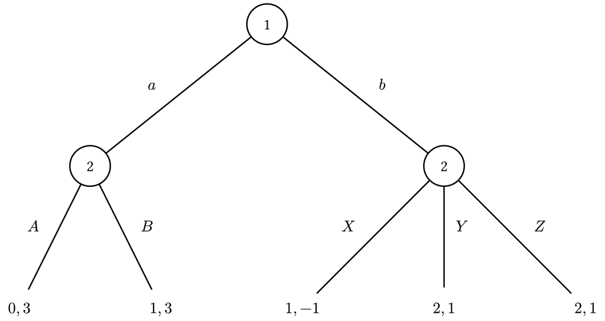

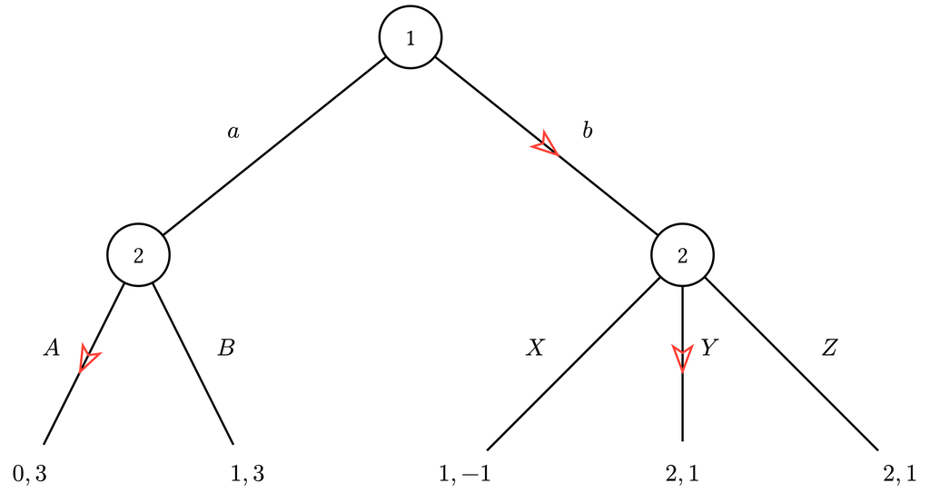

### Strategies in Extensive Form

- Recall: a **strategy** is an information-contingent plan of action
- Therefore, a strategy for any given player must specify what the player will do in *every* state of the world<sup>1</sup>
- In the previous example:
  - $S_1=\{a, b\}$
  - $S_2=\{(A,X), (A,Y), (A,Z), (B,X), (B,Y), (B,Z)\}$
[^1]: respecting information sets

### Information Sets

- We can use dashed lines or bubbles to denote non-degenerate information sets for different players
- Ex: $\hspace{1em}$ I
- II
- III
- IV
- V

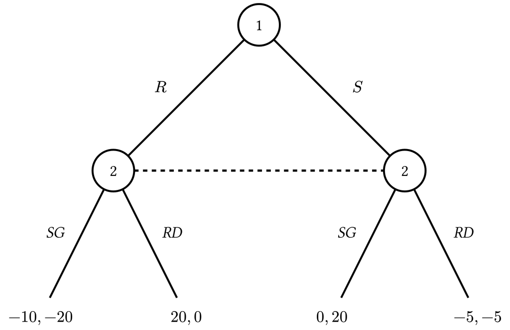

Player 2 does not know whether player 1 played *Remain* or *Swerve*

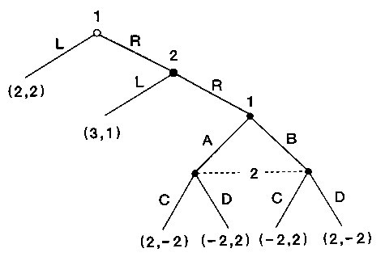

Player 2 sees player 1 play R (or L). If (R,R) is played in the first two stages of the game, when it is player 2’s turn, they do not know whether player 1 played A or B

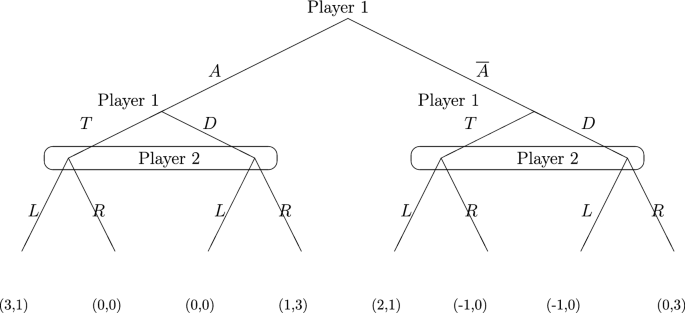

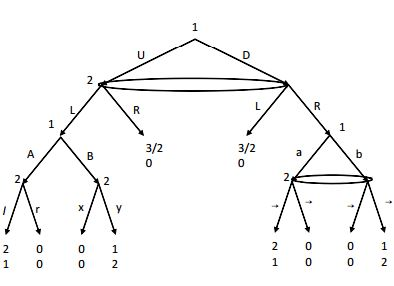

In the first stage of the game, player 2 does not know whether player 1 played $U$ or $D$. Later, they essentially *learn* this move based on how the game progresses. If $(U,L)$ was played, player 2 can see whether $A$ or $B$ was played. If $(D,R)$ was played, player 2 knows this, but they do not know whether player 1 played $a$ or $b$.

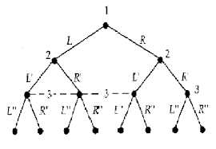

Potato quality. What does player 2 know? What does player 3 know?

### Comparing Information

- Across the following games, compare player 3’s information at their time of play:
- Ex: $\hspace{1em}$ 0.
- 1.
- 2.
- 3.

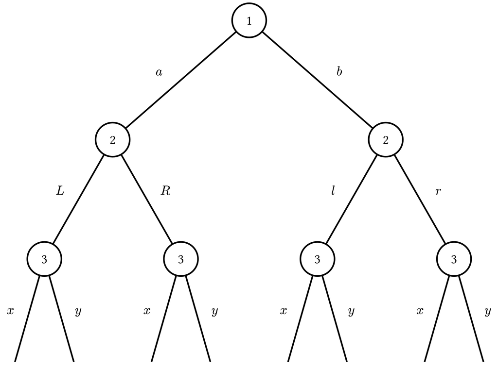

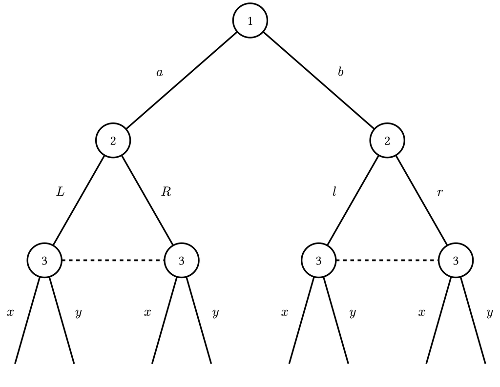

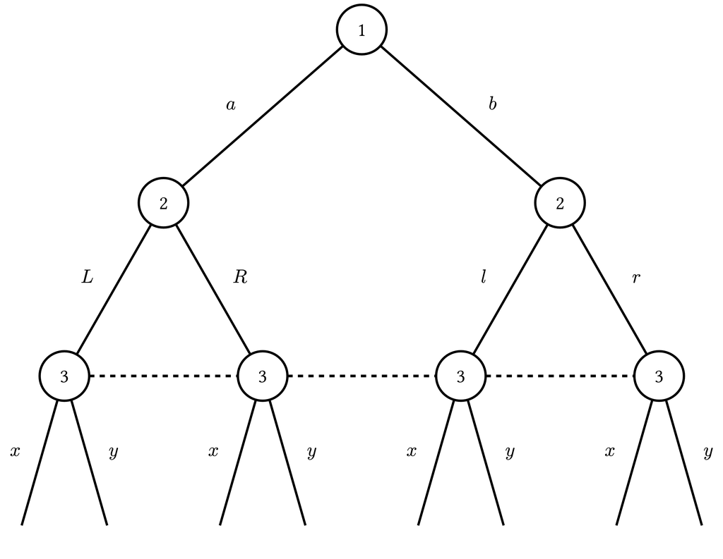

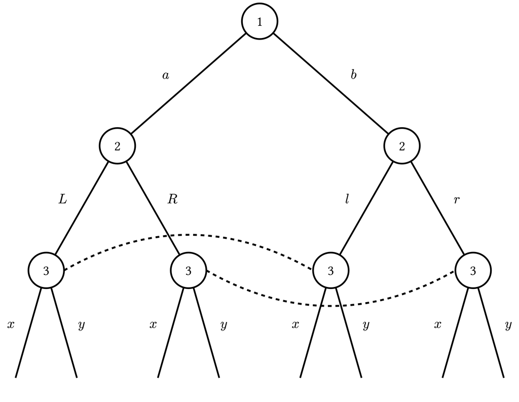

### Make sense?

- Consider the following example

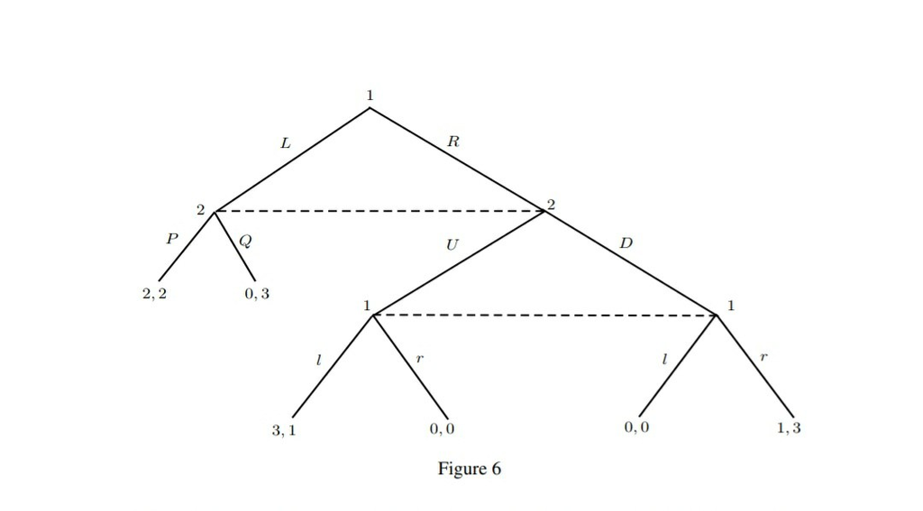

- Write down $S_2$
  - $\{P, Q, U, D\}$?
  - $\{(UP), (DQ)\}$?
  - $\{P, D\}$?
- Does any of these make sense?
  - No!

### Trickery<sup>1</sup>

- Information sets determine actions
- Fact: the actions which a player has available to them within an information set must be the same across all nodes within the information set
- Idea: Assume I’m in a (non-degenerate) information set
  - I.e., I [supposedly] don’t know where I am on the tree
  - Suppose I can play $(A, B, C)$ at one node and $(A, B)$ at another node
    - I can just look at the strategies available to me<sup>2</sup> to determine where I am
    - $\implies$ the supposed information set does not make sense
  - Suppose I can play $(A, B, C)$ at one node and $(X, Y, Z)$ at another node
    - We are still going to say this doesn’t make sense: we will assume I can see the *names* of the strategies available to me
- TL;DR make sure that a player’s actions w/in an information set are constant across all nodes in said information set
[^2]: Tomfoolery, even
[^3]: A player always knows this

### Make sense?

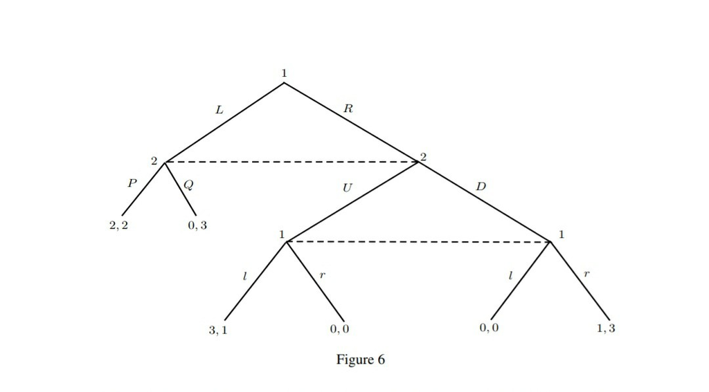

- Write down $S_2$
  - $\{P, Q, U, D\}$?
  - $\{(UP), (DQ)\}$?
  - $\{P, D\}$?
  - None of the above
- This game *doesn’t* make sense: we need to change $P \to U$ and $Q\to D$, or vice versa

### Conversion to Normal Form

- To convert a game from extensive form to normal form:
  - Write down all strategies for each player
  - This defines the size of your payoff matrix
    - #(Player 1 strats) = #(rows)
    - #(Player 2 strats) = #(columns)
  - Fill in game table, ensuring payoffs match to correct outcomes
- This is the easiest way to find all of the (vanilla) NE in an Extensive Form Game

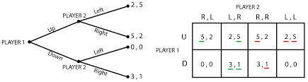

### Computing the number of Strategies

- Want to know how many strategies are in an extensive form game?
- Recall: $S_i$ is player $i$’s set of strategies (aka strategy space)
  - Let $|S_i|$ denote the *number* of strategies in this space
  - E.g. if $S_i=\{\text{Snitch}, \text{Quiet}\}$, then $|S_i|=2$
- $$|S_{i}| = \prod_{\substack{\text{Info sets} \\ \text{for }P_i}} (\text{actions in each info set})$$
- In words: the product of the number of actions in each info set for player $i$, taken over all information sets for player $i$

### Counting Strategies (ex.)

- Compute the size of the strategy space for each player
- Ex 1
- Ans 1
- Ex 2
- Ans 2

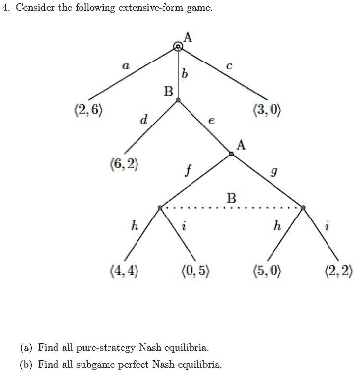

**Ignore the directions in this image.**

- A has 2 info sets
  - First has 3 actions
  - Second has 2 actions
- $|S_A| = 3\cdot 2 = 6$
- B has 2 info sets
  - First has 2 actions
  - Second has 2 actions
- $|S_B| = 2\cdot 2 = 4$

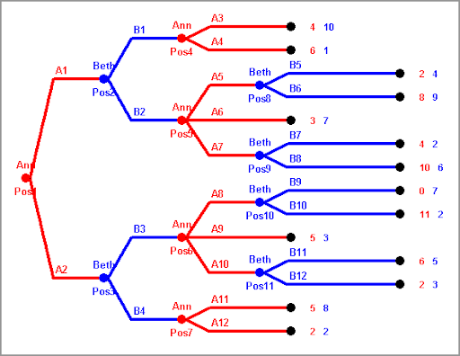

Strategies for Ann? Strategies for Beth?

### The Entrant Game, revised and revisited

- Recall the Entrant game:
- Extensive Form
- Normal Form

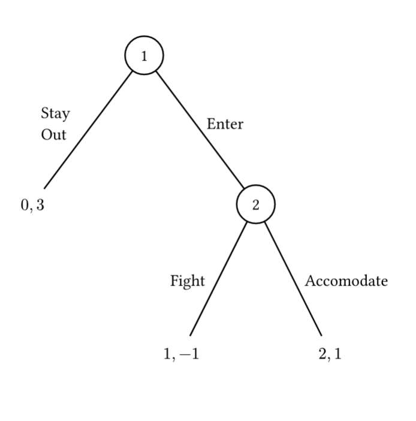

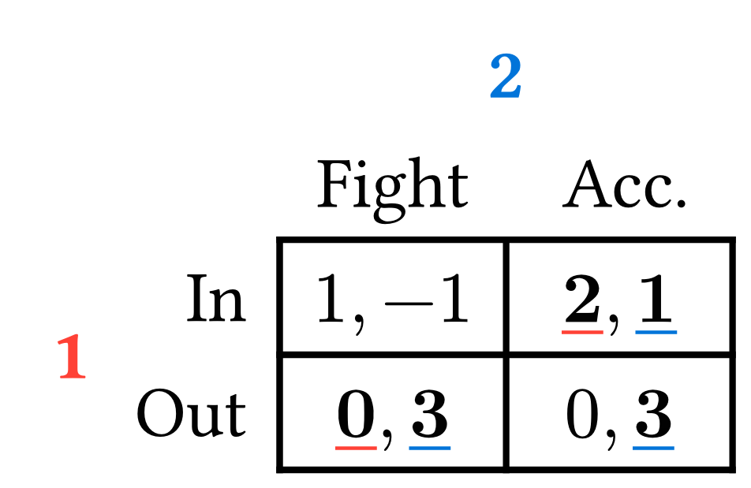

## Why use Extensive Form Games?

### Yay…more definitions

- Let $G$ be a game in extensive form
- A **subgame** of $G$ is
  - a subset of $G$
  - which is itself a game
  - and which doesn’t interfere with the information sets of $G$
- Huh?
  - Start with a non-terminal node in a singleton information set. Trace the node down all of it’s “roots” to the terminal nodes
    - That’s a subgame
  - Put another way: start with a non-payoff node (e.g. a player), which isn’t connected to a dotted line<sup>1</sup>. Follow all the paths that branch down from this node
[^4]: or within a bubble

### Yay…more definitions (cont.)

- Let $G$ be a game in extensive form
- A **subgame** of $G$ is
  - a subset of $G$
  - which is itself a game
  - and which doesn’t interfere with the information sets of $G$
- One more thing:
  - T or F: $5\le 5$
    - True
  - In the same vein, $G$ is a subgame of itself
- When referring to subgames
  - $G$ is the trivial subgame
  - All other subgames are **proper subgames**

### Subgame Examples

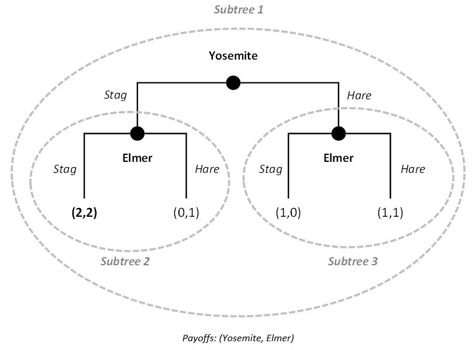

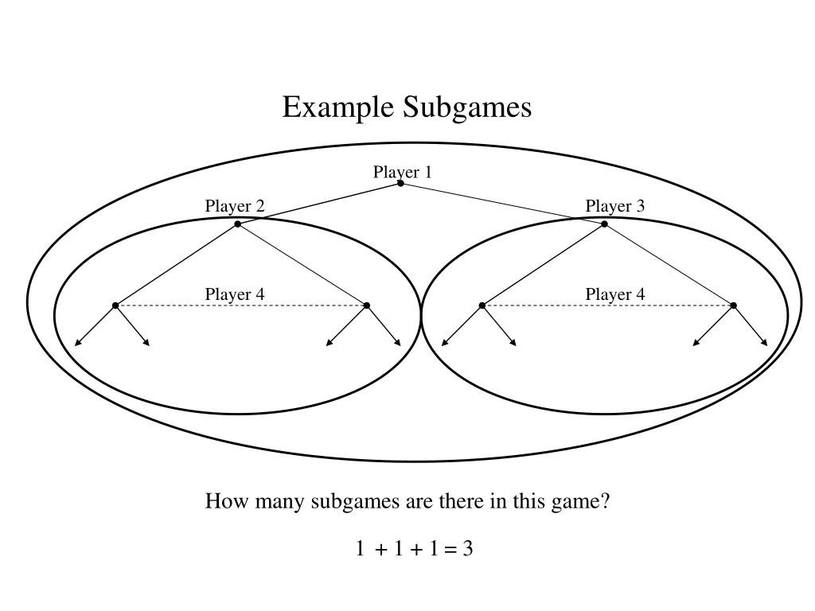

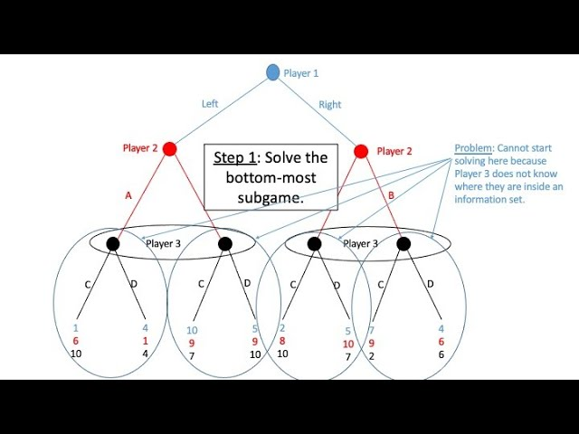

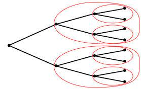

### ain’t no way this mans got another definition slide

- **Def** A Subgame-Perfect Nash Equilibrium (SPNE) for an arbitrary game $G$ is
  1. A Nash Equilibrium for $G$
  2. A Nash Equilibrium in every subgame of $G$
- We can frame this refinement of NE as the result of an additional assumption
  - Common Knowledge of *Sequential* Rationality
    - Players are rational in every subgame

### Good News

- Finding SPNE are pretty straightforward on a game tree
- In fact, given an extensive form game:
  - Need (plain ol’) NE?
    - Write down strategies for each player
    - Convert to Normal Form
    - *Method:* Underline
  - Need SPNE?
    - Use the game tree directly
    - *Method:* Backward Induction<sup>1</sup>
[^5]: IMHO this is a dumb name. Then again, Dixit, Skeath, and McAdams use the term *Rollback Method* and *Rollback Equilibrium*, so there are worse things

### Backward Induction

- For now, we will assume singleton info. sets (no dashed lines)
- Like too much of game theory, this method is hard to write down, but easy to display and easy to perform once you get the hang of it
- Let’s do an example: Entrant Game
- How many subgames?
  - 2 total, 1 proper

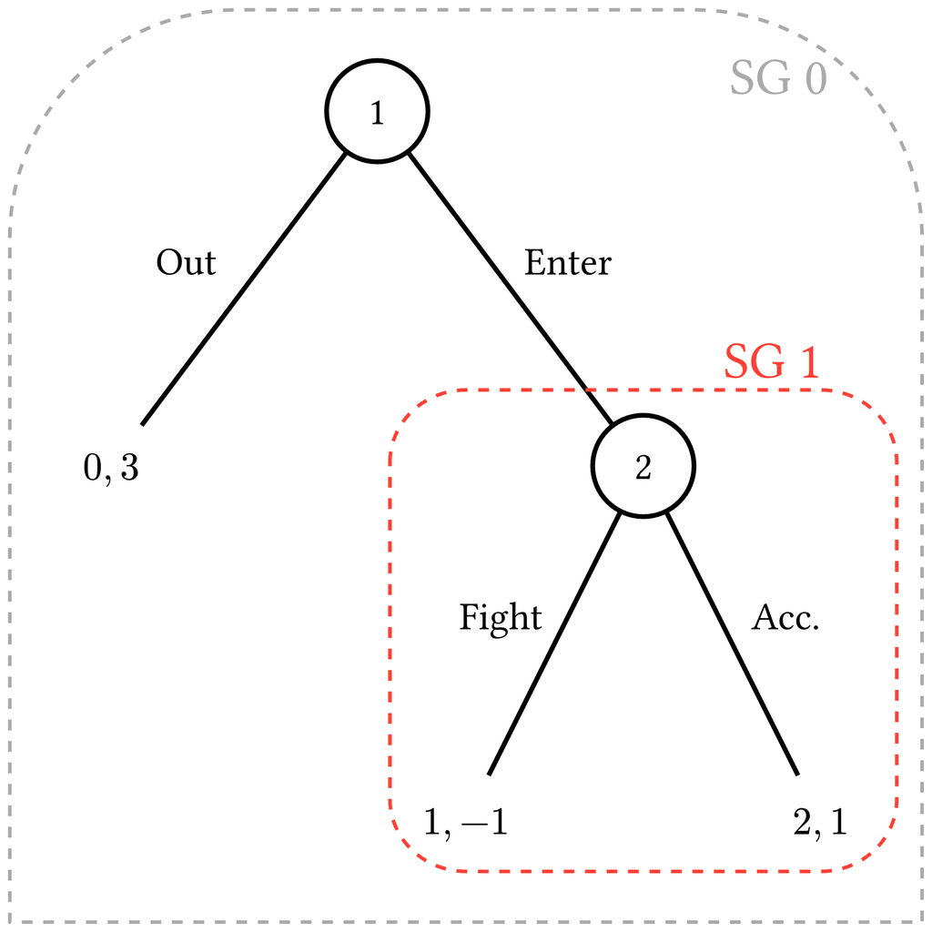

### SPNE: Entrant Game

- Let’s look at the last decision made in the game

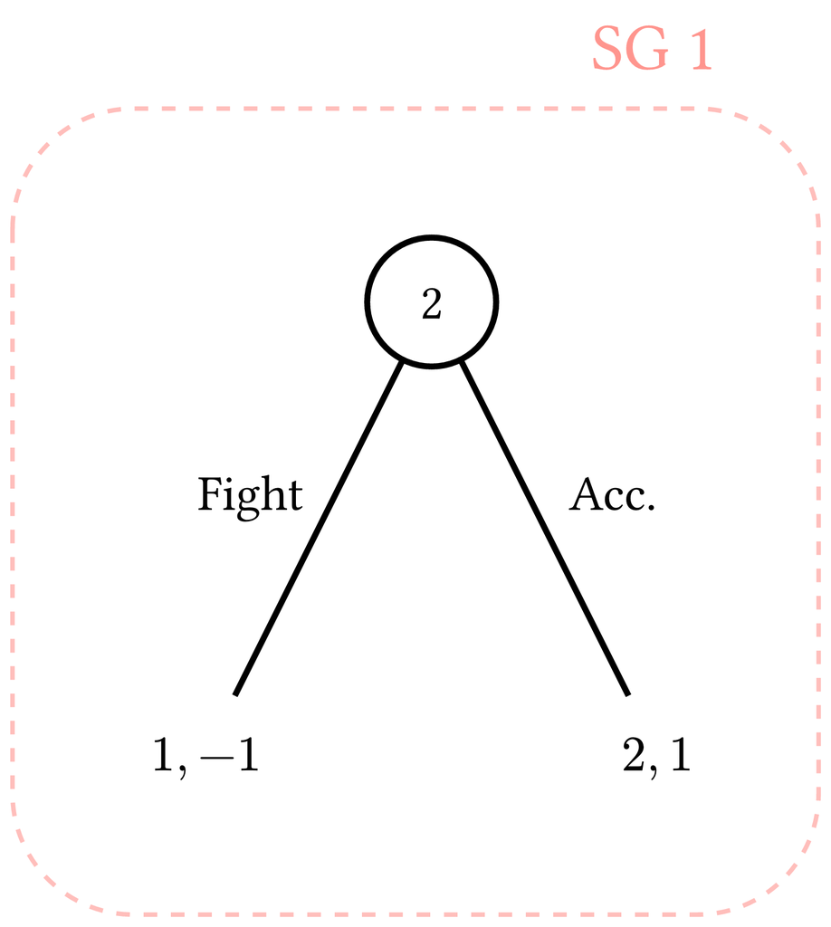

### SPNE: Entrant Game (cont.)

- When it’s player 2’s turn and they reach this subgame, they will rationally pick *Acc.* because $1>-1$

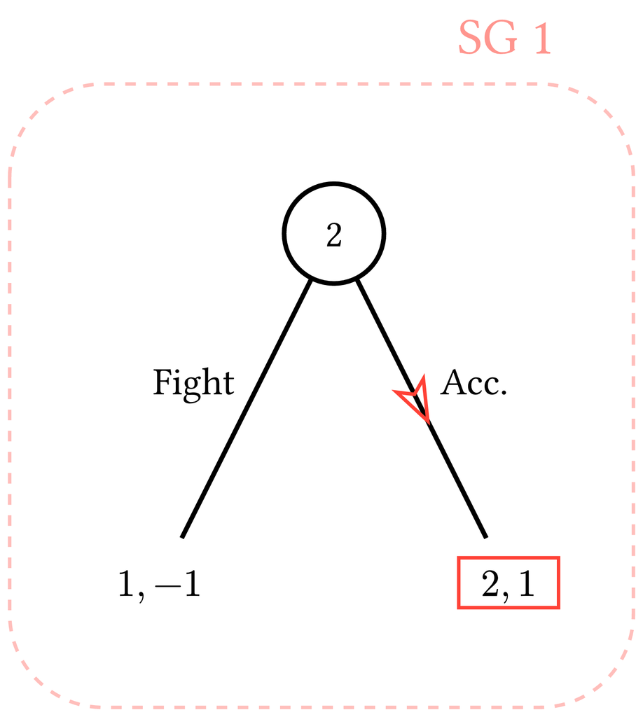

### SPNE: Entrant Game (cont.)

- With common knowledge of sequential rationality, player 1 knows this about player 2
- So, let’s just replace *SG1* with the payoff that will be realized if player 1 plays *Enter*

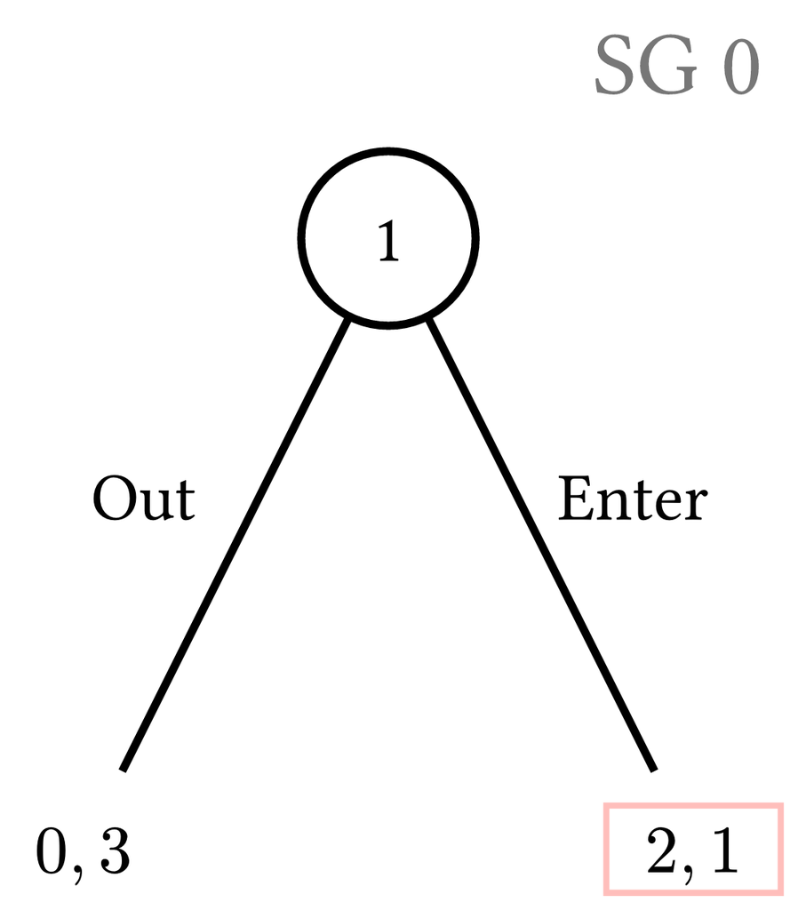

### SPNE: Entrant Game (cont.)

- $2>0$, so player 1 will pick *Enter* rather than *Out*

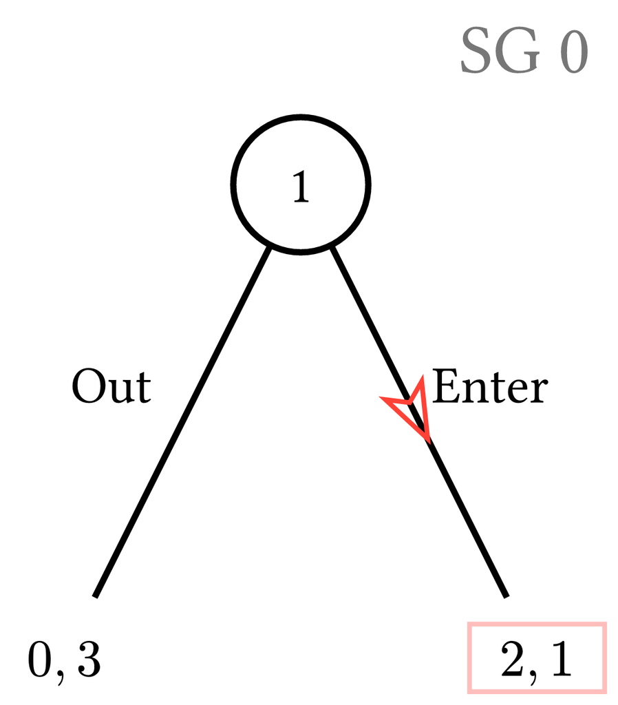

### SPNE: Entrant Game (Solved)

- Therefore, $(Enter, Acc.)$ is the Subgame Perfect Nash Equilibrium

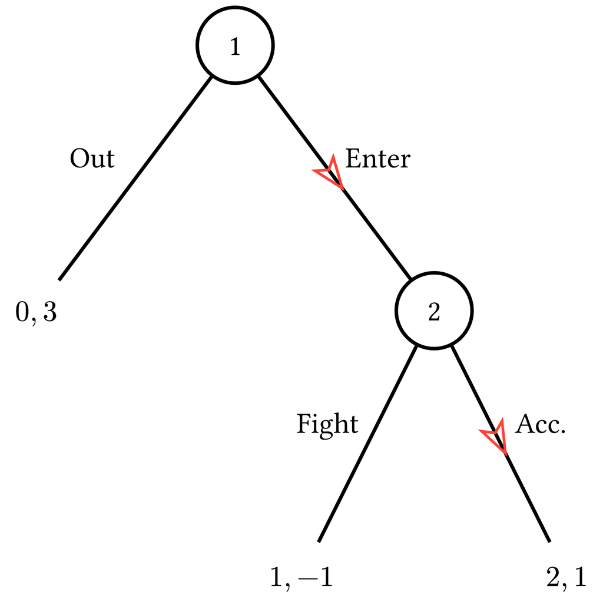

### Kidnapper Game

### Kidnapper Game (NE)

### Kidnapper Game (SPNE)

### Kidnapper Game w/ Imperfect Info.

### Kidnapper Game w/ Imperfect Info. (NF + NE)

### Kidnapper Game w/ Imperfect Info. (SPNE)

### The Centipede Game

### The Centipede Game (cont.)

### The Centipede Game (cont.)